# Lab5MuqianqianLi

Muqianqian

2023-11-26

## Assigment 5

1.Analyze the Salt Lake City dataset. Fit a model that explains suitability for urban development (provide evidence of goodness of model fit). What characteristics contribute to urban development in Salt Lake? What variable might you add to better explain urban development. (1-2 paragraphs) I use General Linear Model to fit the dataset to explain suitability to urban development. Becasue GLM(General Linear Models) can be suitable for response variables thant have error non-normal distribution. We can check the fit of model by calculating the Area under the curve and ROC. We can see the ROC curve is to the upper left corner so the godness of the model is really fit. I will add the distance to the city may better to explain the urban development, because the big city may be constructed for a while and the change of urban will be lesser. - Input the dataset.

```r
library(terra)
#first import the land cover/use data
NLCD_2001 <- rast("NLCD_2001_SL.tif")
NLCD_2004 <- rast("NLCD_2004_SL.tif")
NLCD_2006 <- rast("NLCD_2006_SL.tif")
NLCD_2008 <- rast("NLCD_2008_SL.tif")
NLCD_2011 <- rast("NLCD_2011_SL.tif")
NLCD_2013 <- rast("NLCD_2013_SL.tif")
NLCD_2016 <- rast("NLCD_2016_SL.tif")
# Distance to parks and protected areas in km (Euclidian) for the study area
Park_dist <- rast("Parks_dist_SL.tif")
# Road density for a 1 km neighborhood
Rd_dns1km <- rast("Rd_dns1km_SL.tif")
# Distance to water bodies in km (Euclidean)
WaterDist <- rast("WaterDist_SL.tif")
# elevation
DEM <- rast("DEM_SL.tif")
```

```r
#Create a allrasters layers
allrasters <- c(NLCD_2001, NLCD_2004, NLCD_2006, NLCD_2008, NLCD_2011, NLCD_2013, NLCD_2016, Park_dist, Rd_dns1km, WaterDist,DEM)

# change the stack into a dataframe
library(tidyverse)
allrastersSL <- as.data.frame(allrasters, xy=TRUE)
## Here we are filtering out the no data values (stored as 128)
allrastersSL <- allrastersSL %>%
  filter (NLCD_2001_SL != 128)
head(allrastersSL)
```

```
##          x       y NLCD_2001_SL NLCD_2004_SL NLCD_2006_SL NLCD_2008_SL
## 1 -1330860 2102550           11           52           52           95
## 2 -1330830 2102550           11           52           52           95
## 3 -1330800 2102550           11           11           11           11
## 4 -1330770 2102550           11           11           11           11
## 5 -1330740 2102550           11           11           11           11
## 6 -1330710 2102550           11           11           71           71
##   NLCD_2011_SL NLCD_2013_SL NLCD_2016_SL Parks_dist_SL Rd_dns1km_SL
## 1           95           95           95      1358.308            0
## 2           95           95           95      1343.317            0
## 3           95           11           11      1328.834            0
## 4           95           11           11      1314.876            0
## 5           95           11           95      1301.461            0
## 6           71           71           71      1288.255            0
##   WaterDist_SL DEM_SL
## 1     301.4963   1281
## 2     305.9412   1281
## 3     313.2092   1281
## 4     323.1099   1281
## 5     330.0000   1281
## 6     331.3608   1281
```

```r
#using random sampling to grab a spatial random data
library(leaflet)
sampleSLrnd <- spatSample(allrasters, size=100, "random", cells=TRUE, xy=TRUE)
head(sampleSLrnd)
```

```
##      cell        x       y NLCD_2001_SL NLCD_2004_SL NLCD_2006_SL NLCD_2008_SL
## 1 2169497 -1304160 2067540           42           42           42           42
## 2  770806 -1337850 2090130           52           52           52           52
## 3  917592 -1332990 2087760           95           95           95           95
## 4  292202 -1330530 2097870           11           11           11           11
## 5 1370688 -1326030 2080440           24           24           24           24
## 6 1920737 -1305840 2071560           21           21           21           21
##   NLCD_2011_SL NLCD_2013_SL NLCD_2016_SL Parks_dist_SL Rd_dns1km_SL
## 1           42           42           42     2185.8865  0.000000000
## 2           52           52           52     2634.0273  0.000000000
## 3           95           95           95     5667.4600  0.002754821
## 4           11           11           11        0.0000  0.000000000
## 5           24           24           24     8057.2764  0.217630848
## 6           21           21           21      108.1665  0.042240586
##   WaterDist_SL DEM_SL
## 1    1250.3199   2604
## 2     458.9117   1287
## 3    1083.7435   1286
## 4       0.0000   1282
## 5    2037.3512   1289
## 6    2241.7849   2299
```

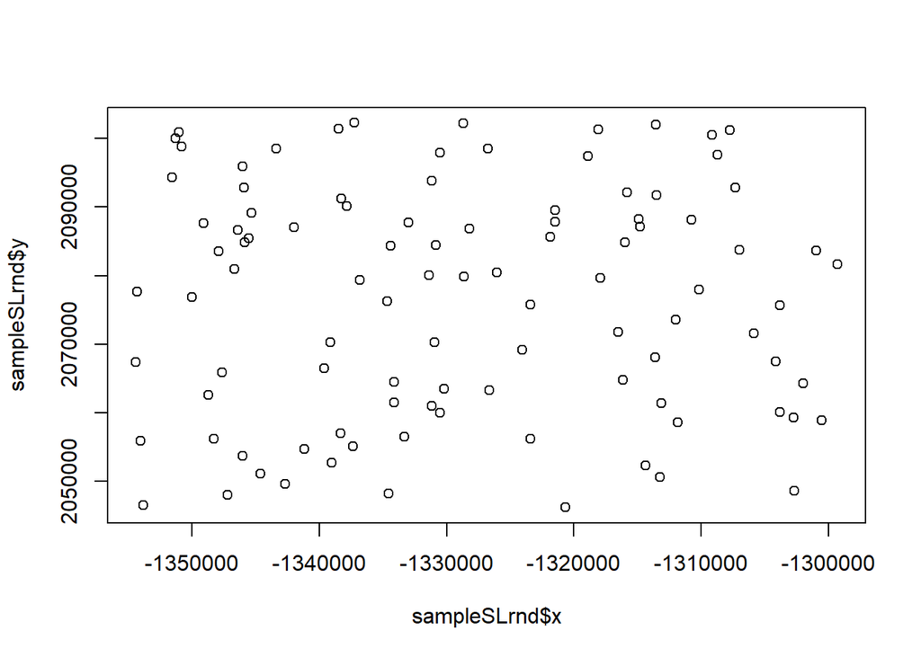

```r
plot(sampleSLrnd$x, sampleSLrnd$y)
```

Spatial autocorrelation

```r
# flatten the spatial data to a dataframe that has lat and long
flat_data <- as.data.frame(sampleSLrnd)
# calculate distances between all the points,
dist_matrix <- as.matrix(dist(cbind(flat_data$x, flat_data$y)))
# and generate a matrix of inverse distance weights.
dist_matix.inv <- 1/dist_matrix
diag(dist_matix.inv) <- 0
library(ape)
Moran.I(sampleSLrnd$Rd_dns1km_SL, dist_matix.inv)
```

```
## $observed
## [1] NA
##
## $expected
## [1] -0.01010101
##
## $sd
## [1] NA
##
## $p.value
## [1] NA
```

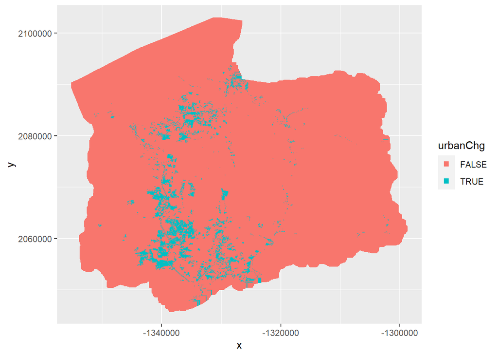

```r
allrastersSL <- allrastersSL %>%
    mutate(urbanChg = (NLCD_2001_SL != 21 & NLCD_2001_SL != 22 & NLCD_2001_SL != 23 & NLCD_2001_SL != 24) &  (NLCD_2016_SL == 21 | NLCD_2016_SL == 22  | NLCD_2016_SL == 23 | NLCD_2016_SL == 24))

ggplot(allrastersSL, aes(y=y, x=x, color=urbanChg)) +
   geom_point(size=2, shape=15) +
   theme()
```